# Лабораторная работа №2

Настройка DNS-сервера

Устинова В. В.

Российский университет дружбы народов, Москва, Россия

12 сентября 2026

# Информация

## Докладчик

- Устинова Виктория Вадимовна
- студент НПИбд-01-24
- Российский университет дружбы народов

## Цель работы

Приобретение практических навыков по установке и конфигурированию DNS-сервера, усвоение принципов работы системы доменных имён.

## Задание

1. Установите на виртуальной машине server DNS-сервер bind и bind-utils (см. раз- дел 2.4.1).
2. Сконфигурируйте на виртуальной машине server кэширующий DNS-сервер (см. раздел 2.4.2).
3. Сконфигурируйте на виртуальной машине server первичный DNS-сервер (см. раз- дел 2.4.3).
4. При помощи утилит dig и host проанализируйте работу DNS-сервера (см. раз- дел 2.4.4).
5. Напишите скрипт для Vagrant, фиксирующий действия по установке и конфигу- рированию DNS-сервера во внутреннем окружении виртуальной машины server. Соответствующим образом внесите изменения в Vagrantfile (см. раздел 2.4.5).

## Загрузка сервера

Запустите виртуальную машину server.На виртуальной машине server войдите под созданным вами в предыдущей работе пользователем и откройте терминал.

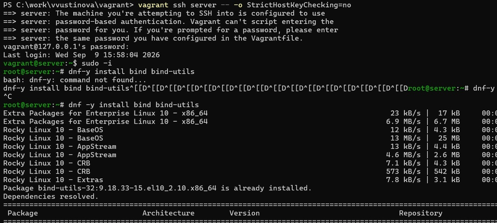

Запускаем машину и подключаемся к ней через shh

##Проверка работы DNS через dig

В качестве упражнения с помощью утилиты dig сделайте запрос, например, к DNS адресу www.yandex.ru:

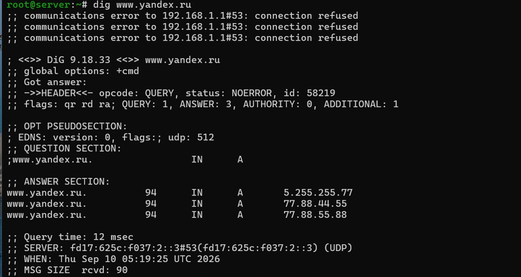

Выполнен запрос dig и видны ответы с ip- адресами

## Анализ конфигурационных файлов DNS.

Проанализировать построчно содержание файлов /etc/resolv.conf, /etc/named.conf, /var/named/named.ca, /var/named/named.localhost, /var/named/named.loopback

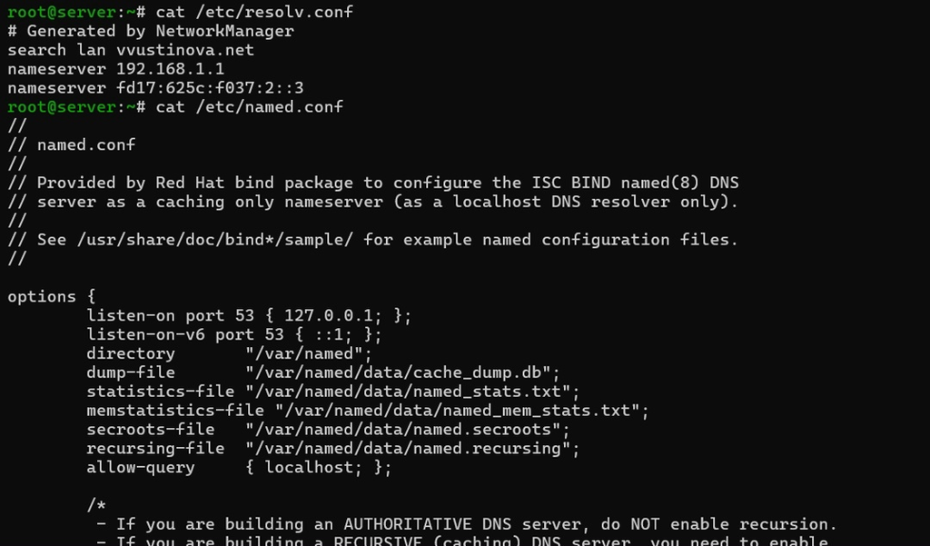

Показано содержимое /etc/resolv.conf и /etc/named.conf с настройками DNS.

## Запуск и автозапуск службы named.

Запустить DNS-сервер командой systemctl start named и включить его автозапуск при загрузке системы командой systemctl enable named.

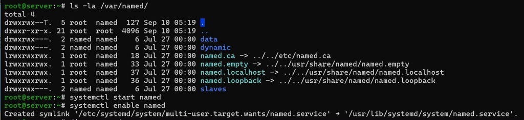

Просмотр каталога /var/named, запуск и включение службы named

## Повторная проверка DNS-запроса

Проанализировать отличие в выводимой информации при выполнении команд dig www.yandex.ru и dig @127.0.0.1 www.yandex.ru.

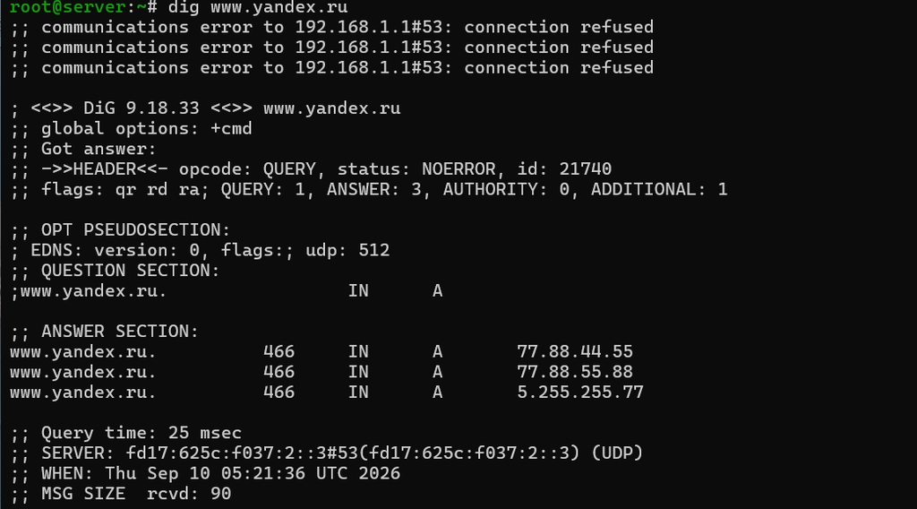

Повторный запрос dig www.yandex.ru, ответ получен от DNS-сервера

## Запрос к локальному DNS-серверу.

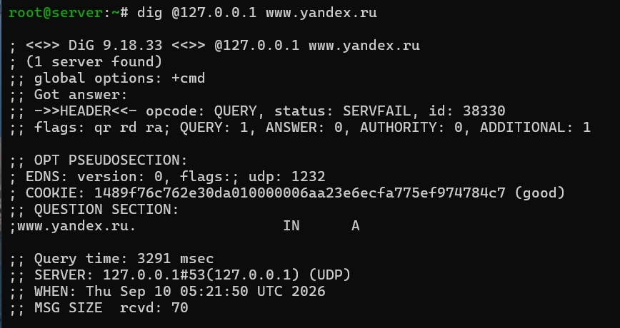

Выполнен запрос dig @127.0.0.1 www.yandex.ru, получен ответ SERVFAIL.

## Настройка DNS через nmcli.

Изменить настройки сетевого соединения eth0 через nmcli: удалить старые DNS, отключить автоматическое получение DNS и указать адрес 127.0.0.1..

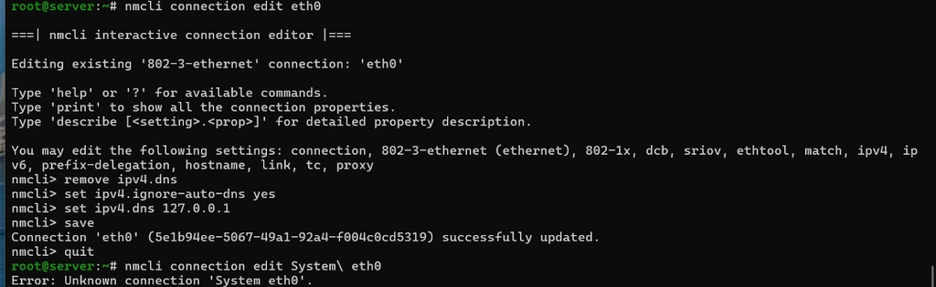

В интерактивном редакторе nmcli настроены параметры DNS для eth0.

## Перезапуск NetworkManager и настройка firewall.

Перезапустить NetworkManager, проверить изменения в /etc/resolv.conf и открыть DNS в межсетевом экране командами firewall-cmd

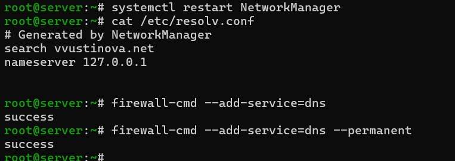

Перезапуск NetworkManager, проверка resolv.conf и добавление службы DNS в firewall

## Проверка прослушивания порта 53.

Убедиться, что DNS-запросы идут через узел server, прослушивающий порт 53. Для этого используется команда lsof | grep UDP.

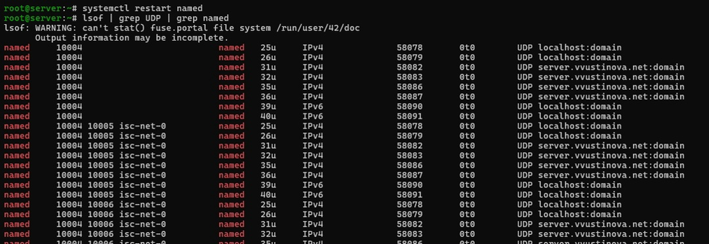

Вывод lsof показывает процессы named, слушающие UDP-порт 53.

## Копирование шаблона зон.

Скопировать шаблон описания DNS-зон named.rfc1912.zones из каталога /etc в каталог /etc/named и переименовать его в vvustinova.net

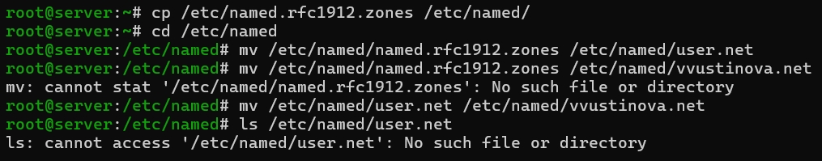

Выполнено копирование и переименование файла зон.

## Создание каталогов прямой и обратной зоны.

В каталоге /var/named создать подкаталоги master/fz и master/rz для файлов прямой и обратной зоны. Скопировать шаблон обратной зоны named.loopback в каталог master/rz.

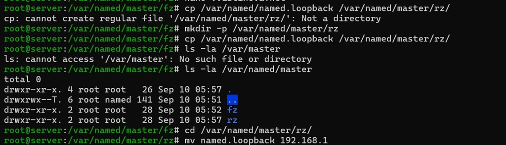

Созданы каталоги, скопирован шаблон обратной зоны.

## Редактирование файла зоны и прав доступа.

Изменить файл прямой зоны /var/named/master/fz/vvustinova.net, указав необходимые DNS-записи. Исправить права доступа к файлам в каталогах /etc/named и /var/named.

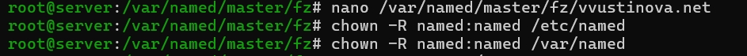

Редактирование файла зоны через nano и смена владельца на named:named

## Копирование шаблона прямой зоны.

Скопировать шаблон прямой DNS-зоны named.localhost в каталог /var/named/master/fz и переименовать его в vvustinova.net

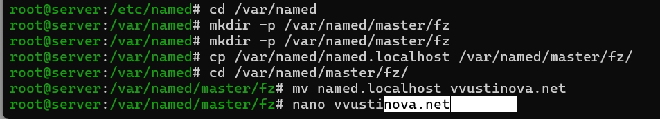

Созданы каталоги, скопирован и переименован шаблон прямой зоны.

## Настройка SELinux для named.

Восстановить метки безопасности SELinux после изменения конфигурационных файлов named и дать разрешение на запись в файлы DNS-зоны.

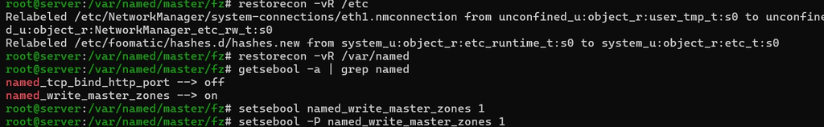

Выполнены restorecon, проверка и установка переключателя named_write_master_zones.

## Проверка работы через journalctl.

Запустить в режиме реального времени расширенный лог системных сообщений journalctl -x -f и перезапустить DNS-сервер для проверки корректности работы.

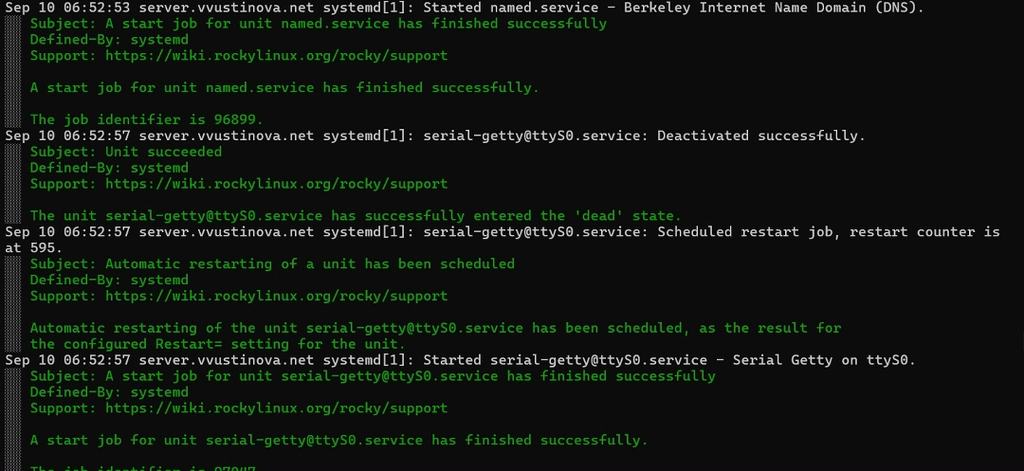

В логе видно успешное завершение запуска службы named.service

## Применение настроек через Vagrant.

Внести изменения в настройки внутреннего окружения виртуальной машины: создать скрипт dns.sh и добавить его вызов в Vagrantfile. Применить изменения командой vagrant reload server –provision

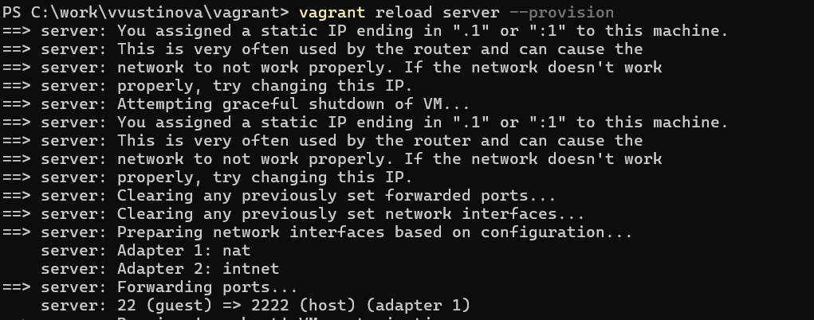

Выполнен vagrant reload server –provision, настройки сервера применяются.

## Выводы

В ходе работы были приобретены практические навыки по установке и конфигурированию DNS-сервера bind. Освоены принципы работы системы доменных имён, настройка кэширующего и первичного DNS-сервера, создание прямой и обратной зон, а также работа с утилитами dig и host. Настроены права доступа, метки SELinux и правила межсетевого экрана. Создан скрипт автоматической настройки DNS-сервера.